# ds-2020-final-project

Ryan Horsey, Scott Engstrom, Pablo Leguizamo, Shashank Koneru

2026-04-24

## Data Description

We are working with a dataset of **42,919 Near-Earth Objects (NEOs)** sourced from NASA’s NeoWs (Near Earth Object Web Service) API. Each row represents one NEO and includes physical characteristics (estimated diameter, absolute magnitude), orbital properties (eccentricity, inclination, semi-major axis), close approach data (miss distance, relative velocity), and a binary classification of whether NASA considers it potentially hazardous.

Our goal is to identify which features best predict hazard classification and build a model that can accurately classify NEOs as hazardous or non-hazardous.

## Data Ingestion

We load the dataset directly from the `.xlsx` file using the `readxl` package. No API calls are needed at this stage since the data has already been collected and saved locally.

```r
library(readxl)
library(dplyr)
```

```r
library(tidyr)
library(ggplot2)
library(rpart)
library(knitr)

class_colors <- c(
  "Not Hazardous" = "#4E79A7",
  "Hazardous" = "#E15759"
)

accent_color <- "#59A14F"

feature_labels <- c(
  absolute_magnitude_h = "Absolute Magnitude H",
  diam_avg_km = "Average Diameter (km)",
  miss_distance_km = "Miss Distance (km)",
  relative_velocity_km_s = "Relative Velocity (km/s)",
  orbital_eccentricity = "Orbital Eccentricity",
  orbital_inclination = "Orbital Inclination",
  orbital_semi_major_axis = "Orbital Semi-Major Axis"
)

format_percent <- function(x, accuracy = 0.1) {
  scales::percent(x, accuracy = accuracy)
}

neo_raw <- read_excel("neo_full_dataset.xlsx")

# Quick look at dimensions and structure
dim(neo_raw)
```

```
## [1] 42919    11
```

```r
glimpse(neo_raw)
```

```
## Rows: 42,919
## Columns: 11
## $ neo_reference_id                  <chr> "2001620", "2001863", "2001915", "20…
## $ name                              <chr> "1620 Geographos (1951 RA)", "1863 A…
## $ absolute_magnitude_h              <dbl> 15.26, 15.35, 18.38, 14.38, 17.21, 1…
## $ est_diam_min_km                   <dbl> 2.3580607, 2.2623249, 0.5604734, 3.5…
## $ est_diam_max_km                   <dbl> 5.2727840, 5.0587123, 1.2532565, 7.9…
## $ miss_distance_km                  <dbl> 5071251, 13378706, 3789658, 16872242…
## $ relative_velocity_km_s            <dbl> 11.762812, 18.079514, 15.120986, 15.…
## $ orbital_eccentricity              <dbl> 0.3355122, 0.6062665, 0.5702246, 0.5…
## $ orbital_inclination               <dbl> 13.335793, 18.378651, 20.399239, 23.…
## $ orbital_semi_major_axis           <dbl> 1.2457769, 2.2601158, 2.5448412, 2.1…
## $ is_potentially_hazardous_asteroid <lgl> TRUE, FALSE, FALSE, FALSE, FALSE, FA…
```

## Data Cleaning

### Step 1: Check for Missing Values

Before cleaning, we get a full picture of where data is missing. This tells us which variables have gaps and helps us decide whether to drop or keep those rows.

```r
colSums(is.na(neo_raw))
```

```
##                  neo_reference_id                              name
##                                 0                                 4
##              absolute_magnitude_h                   est_diam_min_km
##                                13                                13
##                   est_diam_max_km                  miss_distance_km
##                                13                              1762
##            relative_velocity_km_s              orbital_eccentricity
##                              1762                                 4
##               orbital_inclination           orbital_semi_major_axis
##                                 4                                 4
## is_potentially_hazardous_asteroid
##                                 0
```

Two groups of missing values stand out:

- **1,762 rows** are missing both `miss_distance_km` and `relative_velocity_km_s`. These are two of our most important predictor variables, so rows missing both cannot contribute meaningfully to modeling and will be removed.
- A small number of rows (4–13) are missing diameter and orbital columns. These will also be dropped since imputing physical measurements for asteroids is not reliable.
- The `name` column has a few missing values, but it is an identifier field rather than an analysis variable, so it is not used to decide which rows to keep.

```r
required_analysis_cols <- c(
  "neo_reference_id",
  "absolute_magnitude_h",
  "est_diam_min_km",
  "est_diam_max_km",
  "miss_distance_km",
  "relative_velocity_km_s",
  "orbital_eccentricity",
  "orbital_inclination",
  "orbital_semi_major_axis",
  "is_potentially_hazardous_asteroid"
)

neo_clean <- neo_raw %>%
  drop_na(all_of(required_analysis_cols))

# Confirm no remaining missing values in analysis columns
colSums(is.na(select(neo_clean, all_of(required_analysis_cols))))
```

```
##                  neo_reference_id              absolute_magnitude_h
##                                 0                                 0
##                   est_diam_min_km                   est_diam_max_km
##                                 0                                 0
##                  miss_distance_km            relative_velocity_km_s
##                                 0                                 0
##              orbital_eccentricity               orbital_inclination
##                                 0                                 0
##           orbital_semi_major_axis is_potentially_hazardous_asteroid
##                                 0                                 0
```

```r
nrow(neo_clean)
```

```
## [1] 41157
```

```r
tibble(
  dataset = c("Raw data", "Cleaned data"),
  rows = c(nrow(neo_raw), nrow(neo_clean)),
  hazardous_rate = c(
    mean(neo_raw$is_potentially_hazardous_asteroid),
    mean(neo_clean$is_potentially_hazardous_asteroid)
  )
) %>%
  mutate(hazardous_rate = format_percent(hazardous_rate)) %>%
  kable(caption = "Class balance before and after missing-value filtering")
```

Class balance before and after missing-value filtering

| dataset | rows | hazardous_rate |
| --- | --- | --- |
| Raw data | 42919 | 6.4% |
| Cleaned data | 41157 | 6.6% |

### Step 2: Engineer a Mean Diameter Variable

The dataset provides minimum and maximum estimated diameter in kilometers. Rather than keeping both separately, we engineer a single `diam_avg_km` column as the midpoint between the two estimates. This gives us one clean numeric predictor representing size.

```r
neo_clean <- neo_clean %>%
  mutate(diam_avg_km = (est_diam_min_km + est_diam_max_km) / 2)
```

### Step 3: Convert the Target Variable to a Factor

The `is_potentially_hazardous_asteroid` column is currently stored as a logical (`TRUE`/`FALSE`). For modeling and plotting in R, it is better practice to convert this to a **factor** with meaningful labels. This also makes the variable behave correctly in `ggplot2` legends and in classification models.

```r
neo_clean <- neo_clean %>%
  mutate(hazardous = factor(
    is_potentially_hazardous_asteroid,
    levels = c(FALSE, TRUE),
    labels = c("Not Hazardous", "Hazardous")
  )) %>%
  select(-is_potentially_hazardous_asteroid)  # remove original logical column
```

### Step 4: Check for Duplicate Records

We verify there are no duplicate NEO IDs in the dataset. Duplicates could inflate model performance by leaking the same object into both training and test sets.

```r
sum(duplicated(neo_clean$neo_reference_id))
```

```
## [1] 0
```

No duplicates found. Each row represents a unique NEO.

### Step 5: Final Cleaned Dataset

```r
glimpse(neo_clean)
```

```
## Rows: 41,157
## Columns: 12
## $ neo_reference_id        <chr> "2001620", "2001863", "2001915", "2001917", "2…
## $ name                    <chr> "1620 Geographos (1951 RA)", "1863 Antinous (1…
## $ absolute_magnitude_h    <dbl> 15.26, 15.35, 18.38, 14.38, 17.21, 16.24, 16.0…
## $ est_diam_min_km         <dbl> 2.3580607, 2.2623249, 0.5604734, 3.5363478, 0.…
## $ est_diam_max_km         <dbl> 5.2727840, 5.0587123, 1.2532565, 7.9075142, 2.…
## $ miss_distance_km        <dbl> 5071251, 13378706, 3789658, 16872242, 9959875,…
## $ relative_velocity_km_s  <dbl> 11.762812, 18.079514, 15.120986, 15.234490, 10…
## $ orbital_eccentricity    <dbl> 0.3355122, 0.6062665, 0.5702246, 0.5055378, 0.…
## $ orbital_inclination     <dbl> 13.335793, 18.378651, 20.399239, 23.958779, 9.…
## $ orbital_semi_major_axis <dbl> 1.2457769, 2.2601158, 2.5448412, 2.1490513, 1.…
## $ diam_avg_km             <dbl> 3.8154223, 3.6605186, 0.9068649, 5.7219310, 1.…
## $ hazardous               <fct> Hazardous, Not Hazardous, Not Hazardous, Not H…
```

## Visualizations

### Class Balance

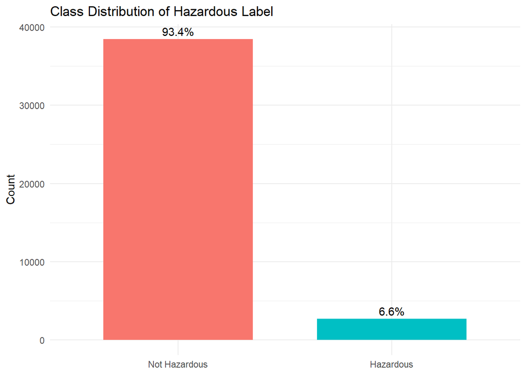

```r
neo_clean %>%
  count(hazardous) %>%
  mutate(prop = n / sum(n)) %>%
  ggplot(aes(x = hazardous, y = n, fill = hazardous)) +
  geom_col(width = 0.7, show.legend = FALSE) +
  geom_text(aes(label = scales::percent(prop, accuracy = 0.1)), vjust = -0.4) +
  labs(
    title = "Class Distribution of Hazardous Label",
    x = NULL,
    y = "Count"
  ) +
  theme_minimal()
```

### Distributions by Hazard Class

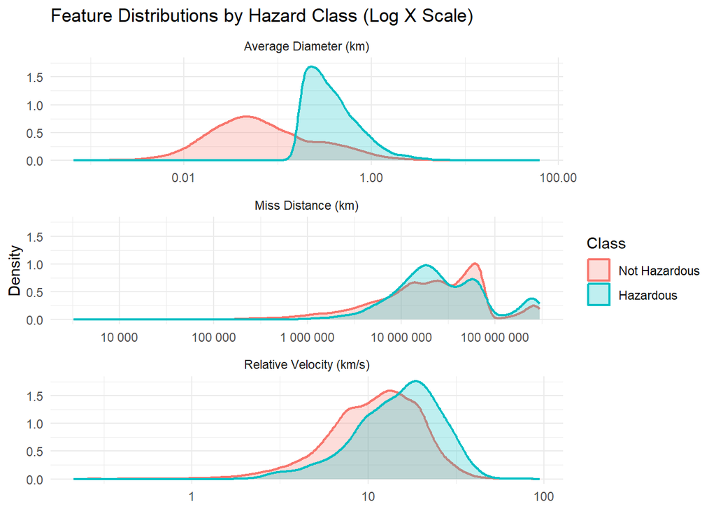

```r
plot_df <- neo_clean %>%
  select(hazardous, diam_avg_km, relative_velocity_km_s, miss_distance_km) %>%
  pivot_longer(
    cols = c(diam_avg_km, relative_velocity_km_s, miss_distance_km),
    names_to = "feature",
    values_to = "value"
  ) %>%
  mutate(
    feature = recode(
      feature,
      diam_avg_km = "Average Diameter (km)",
      relative_velocity_km_s = "Relative Velocity (km/s)",
      miss_distance_km = "Miss Distance (km)"
    )
  )

ggplot(plot_df, aes(x = value, fill = hazardous, color = hazardous)) +
  geom_density(alpha = 0.25, linewidth = 0.8) +
  facet_wrap(~ feature, scales = "free_x", ncol = 1) +
  scale_x_log10(labels = scales::label_number()) +
  labs(
    title = "Feature Distributions by Hazard Class (Log X Scale)",
    x = NULL,
    y = "Density",
    fill = "Class",
    color = "Class"
  ) +
  theme_minimal()
```

### Relative Velocity vs. Miss Distance

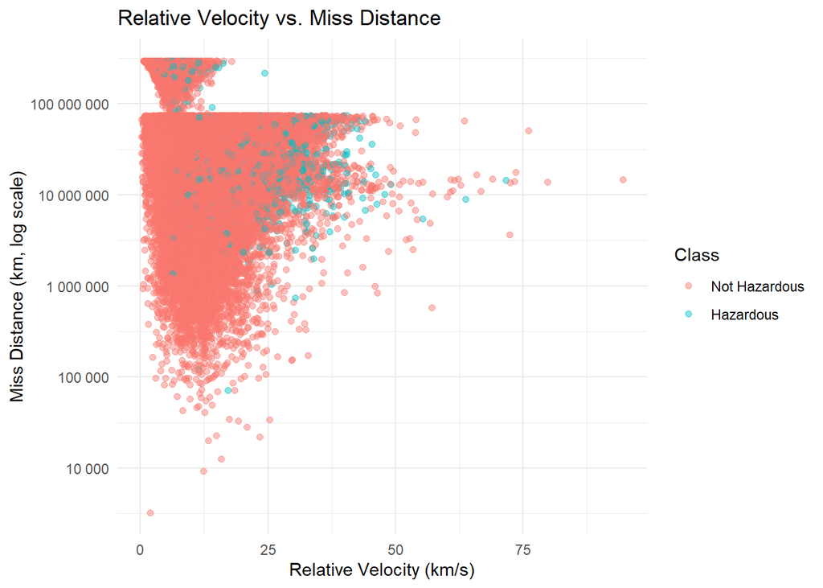

```r
ggplot(
  neo_clean,
  aes(x = relative_velocity_km_s, y = miss_distance_km, color = hazardous)
) +
  geom_point(alpha = 0.45, size = 1.6) +
  scale_y_log10(labels = scales::label_number()) +
  labs(
    title = "Relative Velocity vs. Miss Distance",
    x = "Relative Velocity (km/s)",
    y = "Miss Distance (km, log scale)",
    color = "Class"
  ) +
  theme_minimal()
```

### Correlation Heatmap (Numeric Predictors)

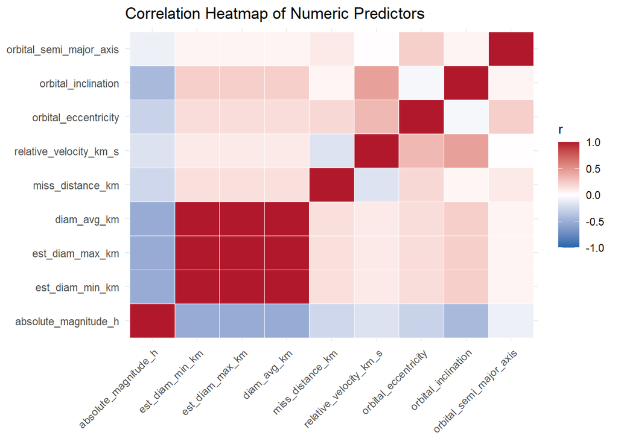

```r
cor_df <- neo_clean %>%
  select(
    absolute_magnitude_h,
    est_diam_min_km,
    est_diam_max_km,
    diam_avg_km,
    miss_distance_km,
    relative_velocity_km_s,
    orbital_eccentricity,
    orbital_inclination,
    orbital_semi_major_axis
  )

cor_mat <- cor(cor_df, use = "complete.obs")

cor_long <- as.data.frame(as.table(cor_mat)) %>%
  rename(var1 = Var1, var2 = Var2, correlation = Freq)

ggplot(cor_long, aes(x = var1, y = var2, fill = correlation)) +
  geom_tile(color = "white") +
  scale_fill_gradient2(
    low = "#2166AC",
    mid = "white",
    high = "#B2182B",
    midpoint = 0,
    limits = c(-1, 1)
  ) +
  labs(
    title = "Correlation Heatmap of Numeric Predictors",
    x = NULL,
    y = NULL,
    fill = "r"
  ) +
  theme_minimal() +
  theme(axis.text.x = element_text(angle = 45, hjust = 1))
```

### Variable Importance (Classification Tree)

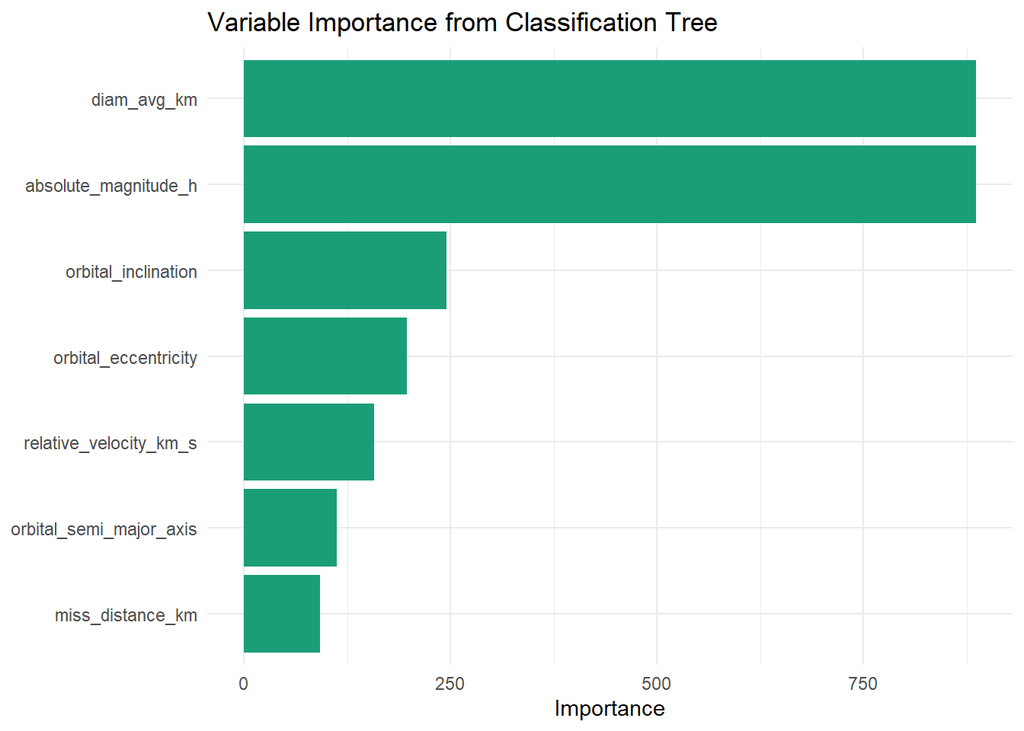

```r
tree_fit <- rpart(
  hazardous ~ diam_avg_km + relative_velocity_km_s + miss_distance_km +
    absolute_magnitude_h + orbital_eccentricity + orbital_inclination +
    orbital_semi_major_axis,
  data = neo_clean,
  method = "class"
)

importance_df <- tibble(
  variable = names(tree_fit$variable.importance),
  importance = as.numeric(tree_fit$variable.importance)
) %>%
  arrange(desc(importance))

ggplot(importance_df, aes(x = reorder(variable, importance), y = importance)) +
  geom_col(fill = "#1B9E77") +
  coord_flip() +
  labs(
    title = "Variable Importance from Classification Tree",
    x = NULL,
    y = "Importance"
  ) +
  theme_minimal()
```

This first tree is an exploratory check rather than the final model evaluation. A proper held-out train/test comparison appears after the remaining research-question plots.

### Orbital Characteristics by Hazard Class

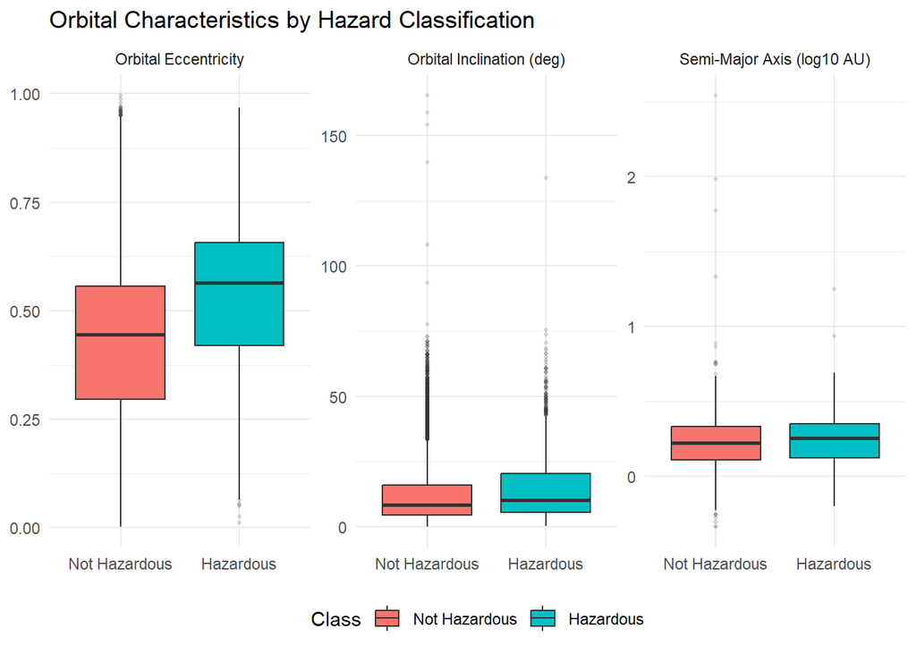

```r
neo_clean %>%
  select(hazardous, orbital_eccentricity, orbital_inclination, orbital_semi_major_axis) %>%
  # log10 transform semi-major axis before pivoting — raw values extend to 300+ AU
  # which collapses the box to nothing; log scale reveals the actual distribution
  mutate(orbital_semi_major_axis = log10(orbital_semi_major_axis)) %>%
  pivot_longer(
    cols = c(orbital_eccentricity, orbital_inclination, orbital_semi_major_axis),
    names_to = "feature",
    values_to = "value"
  ) %>%
  mutate(
    feature = recode(
      feature,
      orbital_eccentricity    = "Orbital Eccentricity",
      orbital_inclination     = "Orbital Inclination (deg)",
      orbital_semi_major_axis = "Semi-Major Axis (log10 AU)"
    )
  ) %>%
  ggplot(aes(x = hazardous, y = value, fill = hazardous)) +
  geom_boxplot(outlier.alpha = 0.15, outlier.size = 0.8) +
  facet_wrap(~ feature, scales = "free_y", ncol = 3) +
  labs(
    title = "Orbital Characteristics by Hazard Classification",
    x = NULL,
    y = NULL,
    fill = "Class"
  ) +
  theme_minimal() +
  theme(legend.position = "bottom")
```

### Absolute Magnitude by Hazard Class

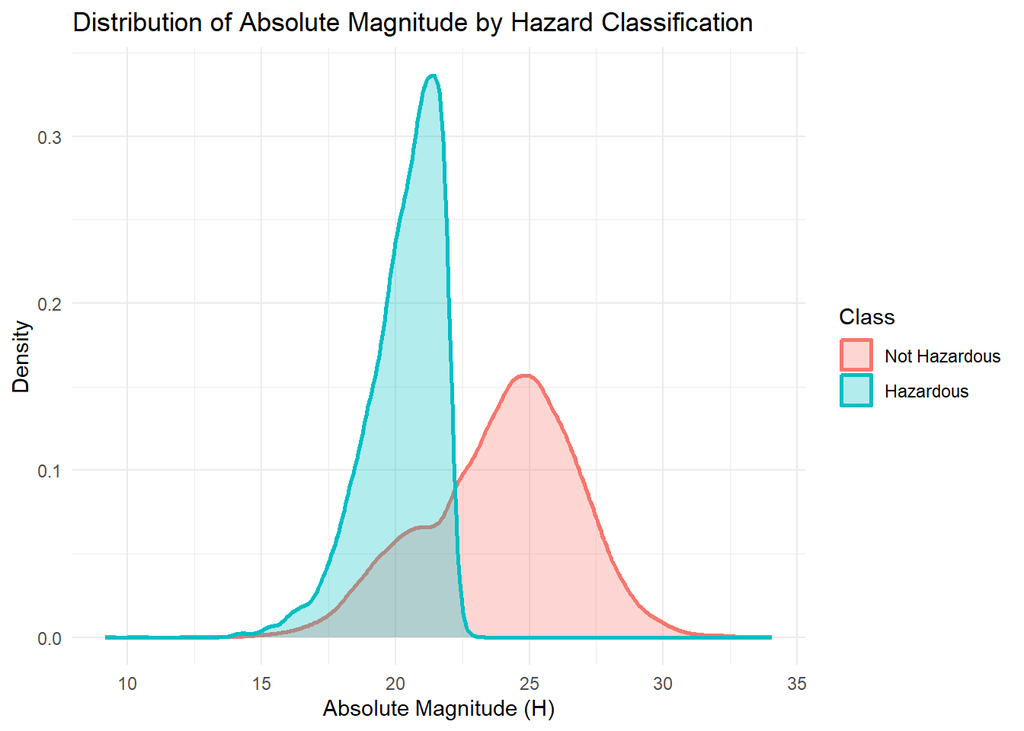

```r
ggplot(neo_clean, aes(x = absolute_magnitude_h, fill = hazardous, color = hazardous)) +
  geom_density(alpha = 0.3, linewidth = 0.9) +
  labs(
    title = "Distribution of Absolute Magnitude by Hazard Classification",
    x = "Absolute Magnitude (H)",
    y = "Density",
    fill = "Class",
    color = "Class"
  ) +
  theme_minimal()
```

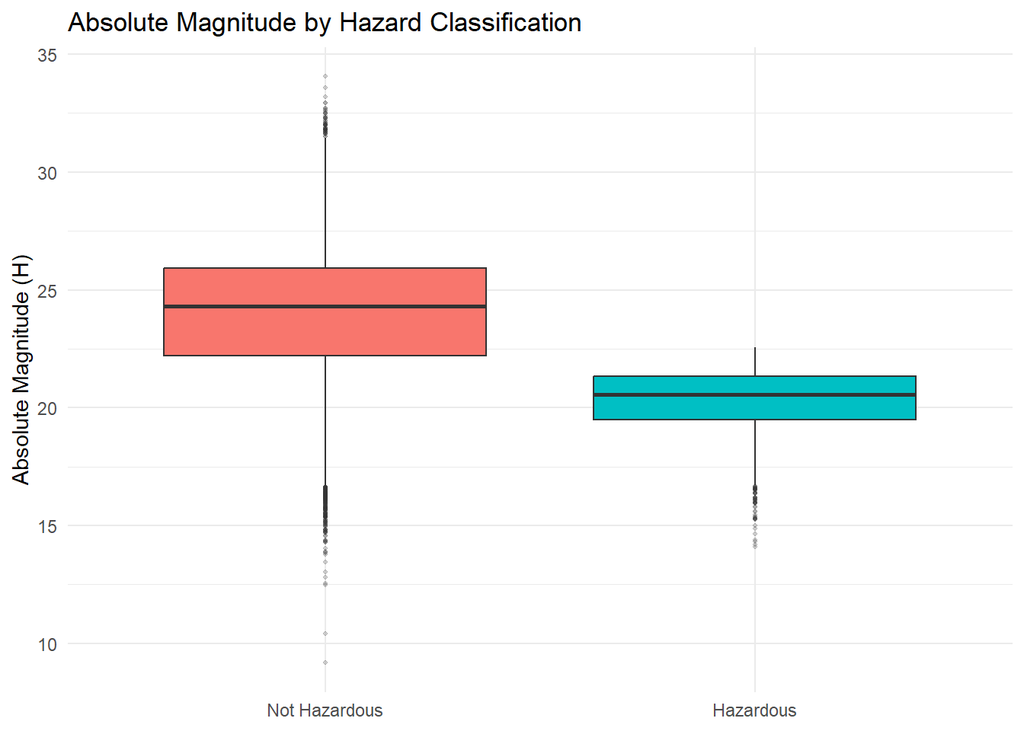

```r
ggplot(neo_clean, aes(x = hazardous, y = absolute_magnitude_h, fill = hazardous)) +
  geom_boxplot(outlier.alpha = 0.2, outlier.size = 0.8, show.legend = FALSE) +
  labs(
    title = "Absolute Magnitude by Hazard Classification",
    x = NULL,
    y = "Absolute Magnitude (H)"
  ) +
  theme_minimal()
```

### Pairwise Scatterplots of Top Predictors

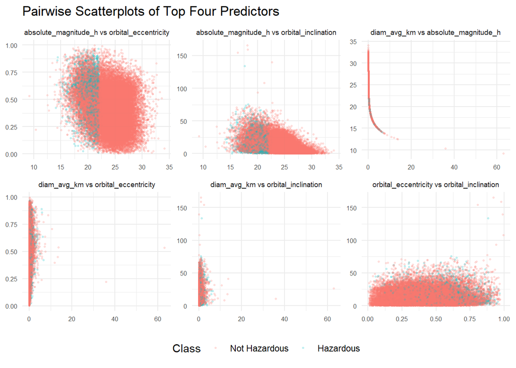

```r
var_pairs <- list(
  list(x = "diam_avg_km",          y = "absolute_magnitude_h"),
  list(x = "diam_avg_km",          y = "orbital_eccentricity"),
  list(x = "diam_avg_km",          y = "orbital_inclination"),
  list(x = "absolute_magnitude_h", y = "orbital_eccentricity"),
  list(x = "absolute_magnitude_h", y = "orbital_inclination"),
  list(x = "orbital_eccentricity", y = "orbital_inclination")
)

pair_df <- bind_rows(lapply(var_pairs, function(p) {
  neo_clean %>%
    transmute(
      hazardous,
      x_val   = .data[[p$x]],
      y_val   = .data[[p$y]],
      panel   = paste(p$x, "vs", p$y)
    )
}))

ggplot(pair_df, aes(x = x_val, y = y_val, color = hazardous)) +
  geom_point(alpha = 0.2, size = 0.6) +
  facet_wrap(~ panel, scales = "free", ncol = 3) +
  labs(
    title = "Pairwise Scatterplots of Top Four Predictors",
    x = NULL,
    y = NULL,
    color = "Class"
  ) +
  theme_minimal() +
  theme(
    legend.position = "bottom",
    strip.text      = element_text(size = 7),
    axis.text       = element_text(size = 6)
  )
```

### Hazard Rate by Asteroid Size

```r
size_hazard_summary <- neo_clean %>%
  mutate(
    size_group = cut(
      diam_avg_km,
      breaks = c(0, 0.03, 0.10, 0.30, 1.00, Inf),
      labels = c("< 0.03", "0.03-0.10", "0.10-0.30", "0.30-1.00", "1.00+"),
      right = FALSE
    )
  ) %>%
  group_by(size_group) %>%
  summarise(
    n = n(),
    hazardous_n = sum(hazardous == "Hazardous"),
    hazard_rate = hazardous_n / n,
    .groups = "drop"
  )

size_hazard_summary %>%
  mutate(hazard_rate = format_percent(hazard_rate)) %>%
  rename(
    `Average Diameter Group (km)` = size_group,
    `Asteroid Count` = n,
    `Hazardous Count` = hazardous_n,
    `Percent Hazardous` = hazard_rate
  ) %>%
  kable(caption = "Hazard rate by average diameter group")
```

Hazard rate by average diameter group

| Average Diameter Group (km) | Asteroid Count | Hazardous Count | Percent Hazardous |
| --- | --- | --- | --- |
| < 0.03 | 10381 | 0 | 0.0% |
| 0.03-0.10 | 14705 | 0 | 0.0% |
| 0.10-0.30 | 8708 | 1178 | 13.5% |
| 0.30-1.00 | 6164 | 1315 | 21.3% |
| 1.00+ | 1199 | 230 | 19.2% |

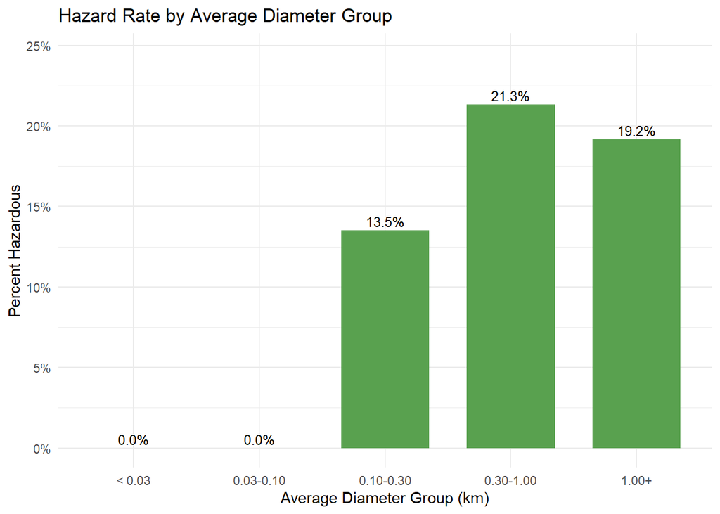

```r
ggplot(size_hazard_summary, aes(x = size_group, y = hazard_rate)) +
  geom_col(fill = accent_color, width = 0.7) +
  geom_text(
    aes(label = scales::percent(hazard_rate, accuracy = 0.1)),
    vjust = -0.35,
    size = 3.4
  ) +
  scale_y_continuous(
    labels = scales::percent_format(accuracy = 1),
    limits = c(0, max(size_hazard_summary$hazard_rate) * 1.15)
  ) +
  labs(
    title = "Hazard Rate by Average Diameter Group",
    x = "Average Diameter Group (km)",
    y = "Percent Hazardous"
  ) +
  theme_minimal()
```

The two smallest diameter groups have a 0.0% hazardous rate. The hazardous rate rises sharply once average diameter reaches 0.10-0.30 km, peaks in the 0.30-1.00 km group, and stays high for asteroids above 1.00 km. This supports the presentation takeaway that NASA’s hazardous label is strongly connected to asteroid size.

### Diameter and Absolute Magnitude Together

```r
magnitude_diameter_corr <- cor(
  neo_clean$absolute_magnitude_h,
  neo_clean$diam_avg_km,
  use = "complete.obs"
)

tibble(
  relationship = "Absolute magnitude H vs. average diameter",
  correlation = round(magnitude_diameter_corr, 3)
) %>%
  kable(caption = "Correlation between absolute magnitude and average diameter")
```

Correlation between absolute magnitude and average diameter

| relationship | correlation |
| --- | --- |
| Absolute magnitude H vs. average diameter | -0.523 |

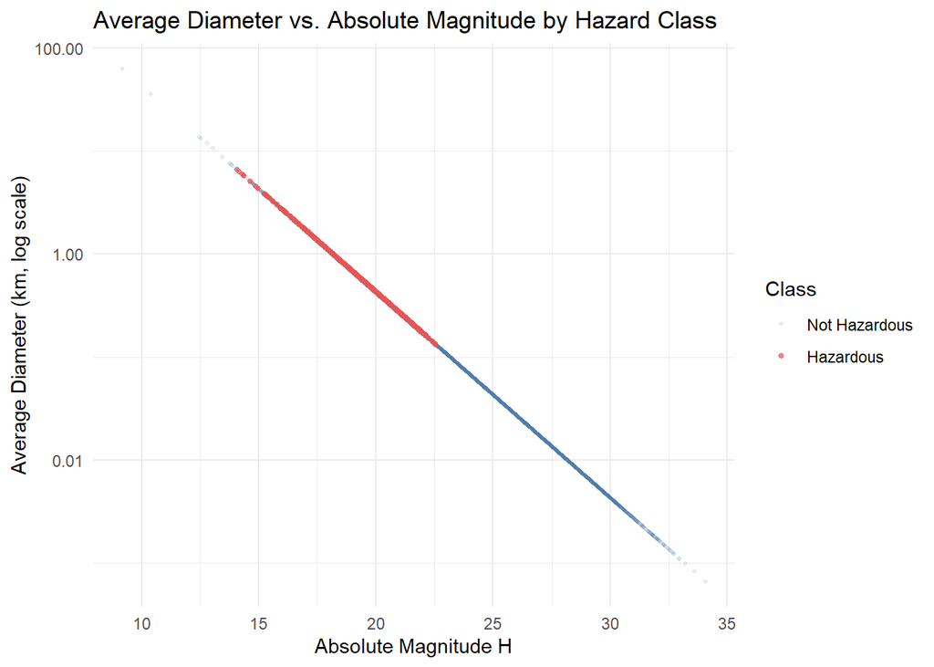

```r
ggplot() +
  geom_point(
    data = filter(neo_clean, hazardous == "Not Hazardous"),
    aes(x = absolute_magnitude_h, y = diam_avg_km, color = hazardous),
    alpha = 0.12,
    size = 0.8
  ) +
  geom_point(
    data = filter(neo_clean, hazardous == "Hazardous"),
    aes(x = absolute_magnitude_h, y = diam_avg_km, color = hazardous),
    alpha = 0.7,
    size = 1.1
  ) +
  scale_y_log10(labels = scales::label_number()) +
  scale_color_manual(values = class_colors) +
  labs(
    title = "Average Diameter vs. Absolute Magnitude by Hazard Class",
    x = "Absolute Magnitude H",
    y = "Average Diameter (km, log scale)",
    color = "Class"
  ) +
  theme_minimal()
```

## Modeling

We use a classification tree because the earlier plots suggest threshold-like behavior: very small asteroids are rarely labeled hazardous, while larger objects are much more likely to be flagged. To keep the evaluation honest, the data is split into stratified training and test sets before fitting the models.

There is an important interpretation limit: NASA’s potentially hazardous asteroid label is partly tied to object size and brightness. Since estimated diameter and absolute magnitude are also closely related to each other, a model using those fields is partly recovering the structure of the label rather than discovering a fully independent warning rule. The full model is therefore best read as an explanatory model for this dataset, not as an independent asteroid warning system.

```r
model_vars_full <- c(
  "absolute_magnitude_h",
  "diam_avg_km",
  "miss_distance_km",
  "relative_velocity_km_s",
  "orbital_eccentricity",
  "orbital_inclination",
  "orbital_semi_major_axis"
)

set.seed(2026)

neo_model <- neo_clean %>%
  select(neo_reference_id, hazardous, all_of(model_vars_full)) %>%
  mutate(row_id = row_number())

train_ids <- neo_model %>%
  group_by(hazardous) %>%
  slice_sample(prop = 0.80) %>%
  ungroup() %>%
  pull(row_id)

train_data <- neo_model %>%
  filter(row_id %in% train_ids) %>%
  select(-row_id, -neo_reference_id)

test_data <- neo_model %>%
  filter(!row_id %in% train_ids) %>%
  select(-row_id, -neo_reference_id)

tibble(
  split = c("Train", "Test"),
  rows = c(nrow(train_data), nrow(test_data)),
  hazardous_rate = c(
    mean(train_data$hazardous == "Hazardous"),
    mean(test_data$hazardous == "Hazardous")
  )
) %>%
  mutate(hazardous_rate = format_percent(hazardous_rate)) %>%
  kable(caption = "Stratified train/test split")
```

Stratified train/test split

| split | rows | hazardous_rate |
| --- | --- | --- |
| Train | 32925 | 6.6% |
| Test | 8232 | 6.6% |

### Evaluation Functions

```r
safe_divide <- function(numerator, denominator) {
  ifelse(denominator == 0, NA_real_, numerator / denominator)
}

confusion_metrics <- function(actual, predicted, positive = "Hazardous") {
  actual <- as.character(actual)
  predicted <- as.character(predicted)
  negative <- "Not Hazardous"

  tp <- sum(actual == positive & predicted == positive)
  tn <- sum(actual == negative & predicted == negative)
  fp <- sum(actual == negative & predicted == positive)
  fn <- sum(actual == positive & predicted == negative)

  tibble(
    tp = tp,
    tn = tn,
    fp = fp,
    fn = fn,
    accuracy = safe_divide(tp + tn, tp + tn + fp + fn),
    recall = safe_divide(tp, tp + fn),
    specificity = safe_divide(tn, tn + fp),
    precision = safe_divide(tp, tp + fp)
  )
}
```

### Fit Classification Tree

```r
full_formula <- as.formula(
  paste("hazardous ~", paste(model_vars_full, collapse = " + "))
)

tree_full <- rpart(
  full_formula,
  data = train_data,
  method = "class",
  control = rpart.control(cp = 0.001, minbucket = 25)
)

tree_full_predicted <- predict(tree_full, newdata = test_data, type = "class")
```

## Results

### Classification Tree Performance

```r
model_metrics <- confusion_metrics(test_data$hazardous, tree_full_predicted) %>%
  select(
    accuracy,
    recall,
    specificity,
    precision,
    tp,
    tn,
    fp,
    fn
  )

model_metrics %>%
  mutate(
    across(c(accuracy, recall, specificity, precision), ~ format_percent(.x))
  ) %>%
  select(
    Accuracy = accuracy,
    Recall = recall,
    Specificity = specificity,
    Precision = precision,
    `True Positives` = tp,
    `True Negatives` = tn,
    `False Positives` = fp,
    `False Negatives` = fn
  ) %>%
  kable(caption = "Classification tree performance on the test data")
```

Classification tree performance on the test data

| Accuracy | Recall | Specificity | Precision | True Positives | True Negatives | False Positives | False Negatives |
| --- | --- | --- | --- | --- | --- | --- | --- |
| 94.2% | 32.5% | 98.6% | 61.7% | 177 | 7577 | 110 | 368 |

The full tree has high specificity, meaning it is good at recognizing non-hazardous asteroids, but recall is the key limitation. Because the hazardous class is small, accuracy can look strong even when many hazardous asteroids are missed. This is why the confusion matrix below is important: it shows how many hazardous asteroids the model catches and misses.

### Confusion Matrix Heatmap

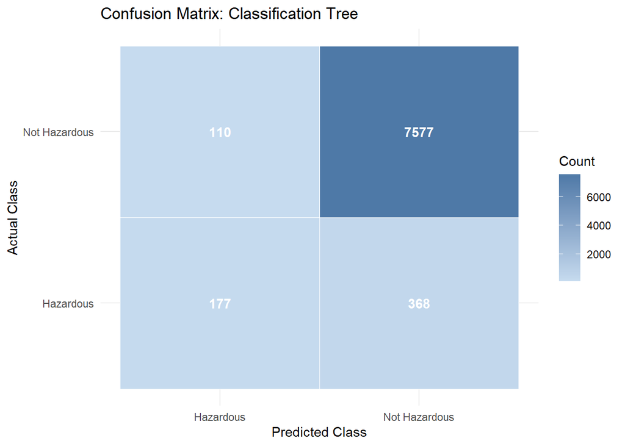

```r
confusion_df <- tibble(
  actual = test_data$hazardous,
  predicted = tree_full_predicted
) %>%
  count(actual, predicted) %>%
  complete(
    actual = levels(test_data$hazardous),
    predicted = levels(test_data$hazardous),
    fill = list(n = 0)
  )

ggplot(confusion_df, aes(x = predicted, y = actual, fill = n)) +
  geom_tile(color = "white") +
  geom_text(aes(label = n), color = "white", fontface = "bold") +
  scale_fill_gradient(low = "#C6DBEF", high = class_colors[["Not Hazardous"]]) +
  labs(
    title = "Confusion Matrix: Classification Tree",
    x = "Predicted Class",
    y = "Actual Class",
    fill = "Count"
  ) +
  theme_minimal()
```

### Classification Tree Variable Importance

```r
importance_df <- tibble(
  variable = names(tree_full$variable.importance),
  importance = as.numeric(tree_full$variable.importance)
) %>%
  mutate(variable = recode(variable, !!!feature_labels)) %>%
  arrange(desc(importance))

importance_df %>%
  mutate(importance = round(importance, 1)) %>%
  kable(caption = "Most important variables in the full classification tree")
```

Most important variables in the full classification tree

| variable | importance |
| --- | --- |
| Absolute Magnitude H | 731.0 |
| Average Diameter (km) | 730.4 |
| Orbital Inclination | 313.2 |
| Orbital Eccentricity | 234.7 |
| Relative Velocity (km/s) | 229.7 |
| Miss Distance (km) | 203.6 |
| Orbital Semi-Major Axis | 197.4 |

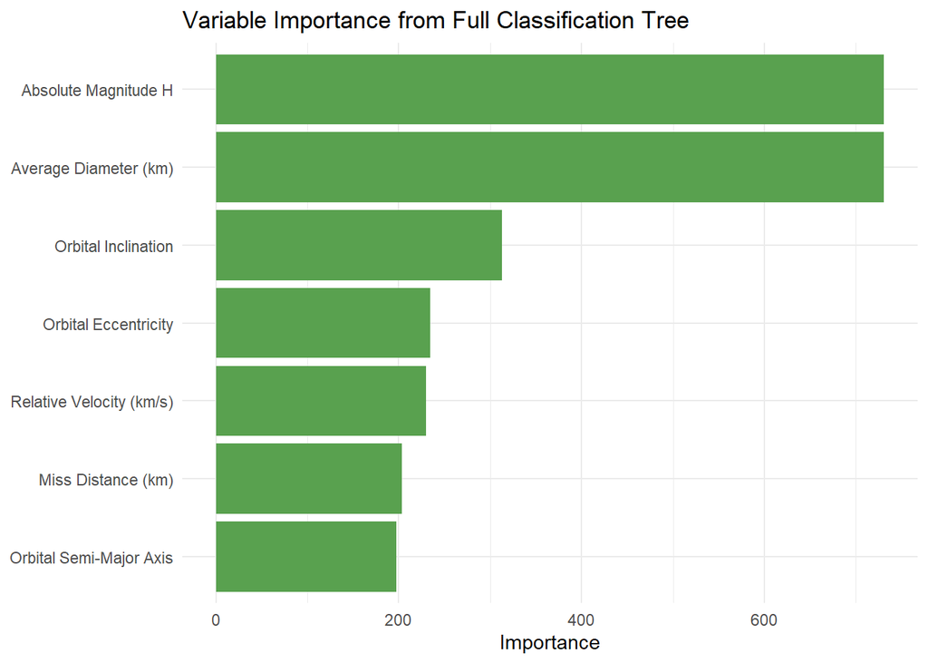

```r
ggplot(importance_df, aes(x = reorder(variable, importance), y = importance)) +
  geom_col(fill = accent_color) +
  coord_flip() +
  labs(
    title = "Variable Importance from Full Classification Tree",
    x = NULL,
    y = "Importance"
  ) +
  theme_minimal()
```

The model results reinforce the visual findings: size and brightness are central to the hazardous label, while the other orbital and close-approach variables provide weaker separation. The full tree is useful as an explanatory check, but its low recall means it should not be interpreted as a real-world asteroid warning system.

## Conclusion

The strongest pattern in the data is that NASA’s hazardous label is closely tied to asteroid size and brightness. This is useful for explaining the dataset, but it also means the strongest predictors are not fully independent of the label definition. Hazardous asteroids are rare in the cleaned dataset, so accuracy alone is misleading: the full tree is much better at ruling out non-hazardous asteroids than at catching all hazardous asteroids. The classification tree should therefore be interpreted as an explanatory check rather than a real-world warning system.

Future work should add Earth MOID, the official orbital-distance part of the PHA definition, and should compare multiple close approaches for the same asteroid rather than relying on one summarized approach field. It would also be useful to test whether one of diameter or absolute magnitude can be dropped without losing much predictive performance.